# *Classification: Supervised Machine Learning*

## *What is classification?*

*Classification is the process of predicting the class of given data points. Classes are sometimes called as targets/ labels or categories. Classification predictive modeling is the task of approximating a mapping function (f) from input variables (X) to discrete output variables (y).* *For example, spam detection in email service providers can be identified as a classification problem. This is s binary classification since there are only 2 classes as spam and not spam. A classifier utilizes some training data to understand how given input variables relate to the class. In this case, known spam and non-spam emails have to be used as the training data. When the classifier is trained accurately, it can be used to detect an unknown email.*

*Classification belongs to the category of supervised learning where the targets also provided with the input data. There are many applications in classification in many domains such as in credit approval, medical diagnosis, target marketing etc.*

### *Types of Classification*

*There are perhaps four main types of classification tasks that you may encounter; they are:*

- *Binary Classification*
- *Multi-Class Classification*
- *Multi-Label Classification*
- *Imbalanced Classification*

#### *Binary Classification*

*Binary classification refers to those classification tasks that have two class labels.*

*Examples include:*

- *Email spam detection (spam or not).*
- *Churn prediction (churn or not).*
- *Conversion prediction (buy or not).*

*Typically, binary classification tasks involve one class that is the normal state and another class that is the abnormal state.*

*For example “not spam” is the normal state and “spam” is the abnormal state. Another example is “cancer not detected” is the normal state of a task that involves a medical test and “cancer detected” is the abnormal state.*

*The class for the normal state is assigned the class label 0 and the class with the abnormal state is assigned the class label 1.*

*Popular algorithms that can be used for binary classification include:*

- *Logistic Regression*
- *k-Nearest Neighbors*
- *Decision Trees*
- *Support Vector Machine*
- *Naive Bayes*

*Some algorithms are specifically designed for binary classification and do not natively support more than two classes; examples include Logistic Regression and Support Vector Machines.*

#### *Multi-Class Classification*

*Multi-class classification refers to those classification tasks that have more than two class labels.*

*Examples include:*

- *Face classification.*
- *Plant species classification.*
- *Optical character recognition.*

*Unlike binary classification, multi-class classification does not have the notion of normal and abnormal outcomes. Instead, examples are classified as belonging to one among a range of known classes.*

*The number of class labels may be very large on some problems. For example, a model may predict a photo as belonging to one among thousands or tens of thousands of faces in a face recognition system.*

*Problems that involve predicting a sequence of words, such as text translation models, may also be considered a special type of multi-class classification. Each word in the sequence of words to be predicted involves a multi-class classification where the size of the vocabulary defines the number of possible classes that may be predicted and could be tens or hundreds of thousands of words in size.*

*Many algorithms used for binary classification can be used for multi-class classification.*

*Popular algorithms that can be used for multi-class classification include:*

- *k-Nearest Neighbors.*
- *Decision Trees.*
- *Naive Bayes.*
- *Random Forest.*
- *Gradient Boosting.*

*Algorithms that are designed for binary classification can be adapted for use for multi-class problems.*

*This involves using a strategy of fitting multiple binary classification models for each class vs. all other classes (called one-vs-rest) or one model for each pair of classes (called one-vs-one).*

- *One-vs-Rest:* *Fit one binary classification model for each class vs. all other classes.*
- *One-vs-One:* *Fit one binary classification model for each pair of classes.*

*Binary classification algorithms that can use these strategies for multi-class classification include:*

- *Logistic Regression.*
- *Support Vector Machine.*

#### *Multi-Label Classification*

*Multi-label classification refers to those classification tasks that have two or more class labels, where one or more class labels may be predicted for each example.*

*Consider the example of photo classification, where a given photo may have multiple objects in the scene and a model may predict the presence of multiple known objects in the photo, such as “bicycle,” “apple,” “person,” etc.*

*This is unlike binary classification and multi-class classification, where a single class label is predicted for each example.*

*Classification algorithms used for binary or multi-class classification cannot be used directly for multi-label classification. Specialized versions of standard classification algorithms can be used, so-called multi-label versions of the algorithms, including:*

- *Multi-label Decision Trees*
- *Multi-label Random Forests*
- *Multi-label Gradient Boosting*

*Another approach is to use a separate classification algorithm to predict the labels for each class.*

#### *Imbalanced Classification*

*Imbalanced classification refers to classification tasks where the number of examples in each class is unequally distributed.*

*Typically, imbalanced classification tasks are binary classification tasks where the majority of examples in the training dataset belong to the normal class and a minority of examples belong to the abnormal class.*

*Examples include:*

- *Fraud detection*
- *Outlier detection*
- *Medical diagnostic tests*

*These problems are modeled as binary classification tasks, although may require specialized techniques.*

*Examples include:*

- *Random Undersampling*
- *SMOTE Oversampling*

*Specialized modeling algorithms may be used that pay more attention to the minority class when fitting the model on the training dataset, such as cost-sensitive machine learning algorithms.*

*Examples include:*

- *Cost-sensitive Logistic Regression.*
- *Cost-sensitive Decision Trees.*
- *Cost-sensitive Support Vector Machines.*

*Finally, alternative performance metrics may be required as reporting the classification accuracy may be misleading.*

*Examples include:*

- *Precision*
- *Recall*
- *F-Measure*

### *Types of Classification Learners*

*There are two types of learners in classification as lazy learners and eager learners.*

- *1. Lazy learners*

*Lazy learners simply store the training data and wait until a testing data appear. When it does, classification is conducted based on the most related data in the stored training data. Compared to eager learners, lazy learners have less training time but more time in predicting.*

*Ex. k-nearest neighbor, Case-based reasoning*

- *2. Eager learners*

*Eager learners construct a classification model based on the given training data before receiving data for classification. It must be able to commit to a single hypothesis that covers the entire instance space. Due to the model construction, eager learners take a long time for train and less time to predict.*

*Ex. Decision Tree, Naive Bayes, Artificial Neural Networks*

# *Logistic Regression*

## *What is Logistic Regression?*

*Logistic Regression is a Generalized Linear Model (GLM)that is used to predict the probability of a categorical dependent variable. In logistic regression, the dependent variable is a binary variable that contains data coded as 1 (yes, success, etc.) or 0 (no, failure, etc.). In other words, the logistic regression model predicts P(Y=1) as a function of X.*

*It is the most important (and probably most used) member of a class of models called generalized linear models. Unlike linear regression, logistic regression can directly predict probabilities (values that are restricted to the (0,1) interval). By the rule of thumb, if the predicted probability is greater or equal to 0.5, then we can label this class as ‘1’; if the predicted probability is smaller to 0.5, then we can label this class as ‘0’.*

## *Assumptions of Logistic Regression*

- *The logistic regression assumes that there is minimal or **no multicollinearity** among the independent variables.*
- *The Logistic regression assumes that the independent variables are **linearly related to the log of odds**.*
- *The logistic regression usually **requires a large sample size** to predict properly (atleast 10 samples per class).*
- *The Logistic regression assumes the observations **doesnot have influential points/outliers**.*

## *Maximum Likelihood Estimation*

*Maximum Likelihood Estimation or MLE can be defined as a method for estimating population parameters (such as the mean and variance for Normal, rate (lambda) for Poisson, etc.) from sample data such that the probability (likelihood) of obtaining the observed data is maximized.*

*In Logistic Regression, Maximum Likelihood (ML) Estimation says coefficients should be chosen in such a way that it maximizes the Probability of Y given X (likelihood). With ML, the computer uses different "iterations" in which it tries different solutions until it gets the maximum likelihood estimates.*

*This means finding parameters that maximize the probability p of event 1 and (1-p) of non-event 0.*

*The basic idea is that if the data were to have been generated by the model, what parameters were most likely to have been used? That is, what is the probability of seeing the data , given a specific set of parameters?*

_Logistic regression applies maximum likelihood estimation after transforming the dependent variable into a *logit variable (natural log of the odds(Odds describes the ratio of success to ratio of failures = p/1-p) of the dependent variable occurring or not)* with respect to independent variables. In this way, logistic regression estimates the probability of a certain event occurring._

### *Why log(odds)?*

- *Probability ranges from 0 to 1*
- *Odds range from 0 to ∞*
- *Log Odds range from −∞ to ∞*

*By converting probability to log(odds), we expand the range from [0, 1] to [- ∞,+∞ ]. By fitting model on probability we will encounter a restricted range problem, and also by applying log transformation, we cover-up the non-linearity involved and we can just fit with a linear combination of variables*

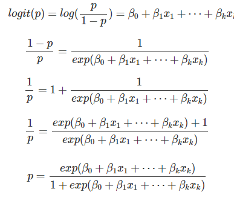

*So now that we have the predicted probabilities for our training data observations, we will plot them where y-axis ranges from 0 to 1 (target variable) and x-axis represents independent variable (predictor) to get the sinusoidal curve (**SIGMOID CURVE**) that classifies the data.*

*So we can calculate maximum likelihood estimation by `MLE = p0*p1*p2..pn*(1-p0)*(1-p1)*(1-p2)....(1-pn)` and iterate to get best parameters to get maximum value.*

*[Reference 1](https://medium.com/analytics-vidhya/logistic-regression-the-journey-from-odds-to-log-odds-to-mle-to-woe-to-lets-see-where-it-2982d1584979), [Reference 2](https://sebastianraschka.com/faq/docs/logistic-why-sigmoid.html)*

## *Sigmoid Function*

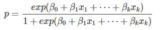

*This is known as the Sigmoid function (outputs the conditional probabilities of the prediction) and it gives an S-shaped curve. It always gives a value of probability ranging from 0<p<1.*

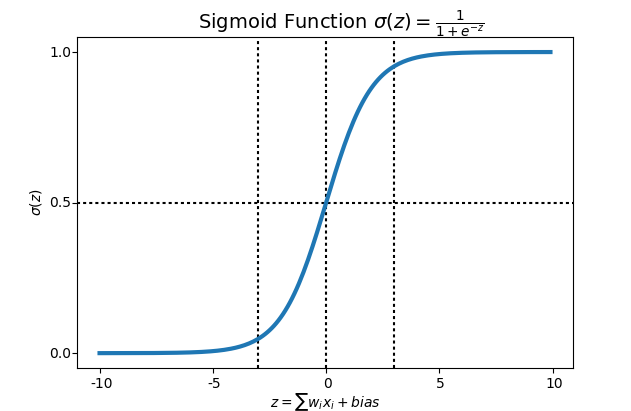

*So, if the value of z goes to positive infinity then the predicted value of y will become 1 and if it goes to negative infinity then the predicted value of y will become 0. And if the outcome of the sigmoid function is more than 0.5 (Decision Boundary) then we classify that label as class 1 or positive class and if it is less than 0.5 than we can classify it to negative class or label as class 0.*

## *Decision Boundary*

```
p≥0.5,class=1
p<0.5,class=0
```

*For example, if our threshold was .5 and our prediction function returned .7, we would classify this observation as positive. If our prediction was .2 we would classify the observation as negative. For logistic regression with multiple classes we could select the class with the highest predicted probability.*

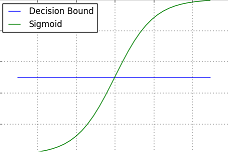

*Bonus*: *Why logistic regression is considered Linear Model? It's because the decision boundary is linear in x . To be more specific, the decision boundary in this case is given by wTx=0 (a hyperplane). When can also generate a non-linear decision boundary but then that instance would be non-linear logistic regression same as non-linear SVM.*

## *Why can't Linear regression be used for Classification?*

- *Error terms will tend to be large at the middle values of X (independent variable) and small at the extreme values, which is the violation of linear regression assumptions that errors should have zero mean and should be normally distributed.*
- *Predicted values may be out of range of 0 & 1.*
- *With the extreme values in the dataset the best fit line will change and slope will also change, hence we wil have to change the threshold value, which affects the other predictions.*

*e.g.*

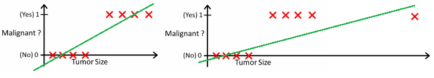

*In image 1 a linear regression model is designed to have threshold of 0.5 to divide classes, but addition of one extreme value in image 2 has made all those probabilities for previous point change and now to accomodate those in class 1 the threshold needs to be changed to 0.2.*

*We cannot change the hypothesis each time a new sample arrives. Instead, we should learn it off the training set data, and then (using the hypothesis we've learned) make correct predictions for the data we haven't seen before. This is why we do not use Linear regression for Classification problems.*

## *Cost Function/Log Loss/Cross Binary Entropy*

*The cost function represents optimization objective i.e. we create a cost function and minimize it so that we can develop an accurate model with minimum error.*

*If we try to use the cost function of the linear regression in ‘Logistic Regression’ then it would be of no use as Squaring the prediction would end up being a non-convex function with many local minimums, in which it would be very difficult to minimize the cost value and find the global minimum.*

*For logistic regression, the Cost function is defined as:*

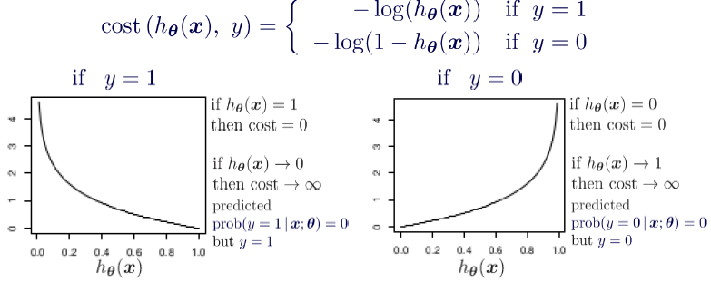

*This equation can be compressed to:*

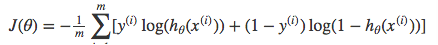

_This cost function is also called *LOG LOSS* or *CROSS BINARY ENTROPY*._

*Cross-entropy loss increases as the predicted probability diverges from the actual label.*

*As the predicted probability decreases, however, the log loss increases rapidly.*

*To minimize the cost function we have to run the **gradient descent** function on each parameter.*

*[Reference](https://medium.com/analytics-vidhya/derivative-of-log-loss-function-for-logistic-regression-9b832f025c2d)*

## *Weight of Evidence(WOE) and Information Value(IV)*

*Weight of Evidence (WoE) describes the relationship between a predictor and a binary dependent variable. Information Value (IV) is the measurement of that relationship’s power. Based on its role, IV can be used as a base for attributes selection.*

*These two terms have been in existence in credit scoring world for more than 4-5 decades. They have been used as a benchmark to screen variables in the credit risk modeling projects such as probability of default. They help to explore data and screen variables. It is also used in marketing analytics project such as customer attrition model, campaign response model etc.*

### *Weight of Evidence (WOE)*

*The weight of evidence tells the predictive power of an independent variable in relation to the dependent variable.*

_Since it evolved from credit scoring world, it is generally described as a measure of the separation of good and bad customers. "Bad Customers" refers to the customers who defaulted on a loan. and "Good Customers" refers to the customers who paid back loan.__

*Weight of Evidence (WOE) helps to transform a continuous independent variable into a set of groups or bins based on similarity of dependent variable distribution i.e. number of events and non-events.*

*For continuous independent variables:* *First, create bins (categories / groups) for a continuous independent variable and then combine categories with similar WOE values and replace categories with WOE values. Use WOE values rather than input values in your model.*

*For categorical independent variables:* *Combine categories with similar WOE and then create new categories of an independent variable with continuous WOE values. In other words, use WOE values rather than raw categories in your model. The transformed variable will be a continuous variable with WOE values. It is same as any continuous variable.*

*Why combine categories with similar WOE?*

*It is because the categories with similar WOE have almost same proportion of events and non-events. In other words, the behavior of both the categories is same.*

*Rules related to WOE*

- *Each category (bin) should have at least 5% of the observations.*
- *Each category (bin) should be non-zero for both non-events and events.*
- *The WOE should be distinct for each category. Similar groups should be aggregated.*
- *The WOE should be monotonic, i.e. either growing or decreasing with the groupings.*
- *Missing values are binned separately.*

*Number of Bins (Groups)*

*In general, 10 or 20 bins are taken. Ideally, each bin should contain at least 5% cases. The number of bins determines the amount of smoothing - the fewer bins, the more smoothing. If someone asks you ' "why not to form 1000 bins?" The answer is the fewer bins capture important patterns in the data, while leaving out noise. Bins with less than 5% cases might not be a true picture of the data distribution and might lead to model instability.*

*Handle Zero Event/ Non-Event*

*If a particular bin contains no event or non-event, you can use the formula below to ignore missing WOE. We are adding 0.5 to the number of events and non-events in a group.*

```
AdjustedWOE = ln (((Number of non-events in a group + 0.5) / Number of non-events)) / ((Number of events in a group + 0.5) / Number of events))
```

*WOE Advantage:*

*The advantages of WOE transformation are*

- *Handles missing values*
- *Handles outlier*
- *The transformation is based on logarithmic value of distributions. This is aligned with the logistic regression output function*
- *No need for dummy variables*
- *By using proper binning technique, it can establish monotonic relationship (either increase or decrease) between the independent and dependent variable*

### *Information Value (IV)*

*Information value is one of the most useful technique to select important variables in a predictive model. It helps to rank variables on the basis of their importance. The IV is calculated using the following formula:*

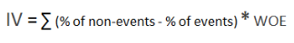

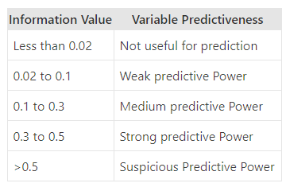

*Important Points*

- *Information value increases as bins / groups increases for an independent variable. We have to be careful when there are more than 20 bins as some bins may have a very few number of events and non-events.*
- *Information value should not be used as a feature selection method when you are building a classification model other than binary logistic regression (for eg. random forest or SVM) as it's designed for binary logistic regression model only.*

*[Reference 1](https://www.kaggle.com/pavansanagapati/weight-of-evidence-woe-information-value-iv), [Reference 2](https://www.listendata.com/2015/03/weight-of-evidence-woe-and-information.html)*

*BONUS:* *Standardization of features in Logistic Regression is not necessary. Standardizing the features will only change the coefficients value and not the predictions.*

```python
# Packages / libraries

import os #provides functions for interacting with the operating system

import numpy as np
import pandas as pd
from matplotlib import pyplot as plt
import seaborn as sns

%matplotlib inline

import scikitplot as skplt # for plotting statistical graphs

# Increases the size of sns plots
sns.set(rc={'figure.figsize':(6,4)})

import warnings
warnings.filterwarnings('ignore')
```

```python
names = 'response age sex on_thyroxine query_on_thyroxine antithyroid_medication thyroid_surgery query_hypothyroid query_hyperthyroid pregnant \
sick tumor lithium goitre TSH_measured TSH T3_measured \
T3 TT4_measured TT4 T4U_measured T4U FTI_measured FTI TBG_measured TBG'

names = names.split(' ')
```

```python
# Reading dataset

data = pd.read_csv(r'C:\Users\PiyushSin\Downloads\hypothyroid.csv',index_col=False,names=names,na_values=['?'])
data.head()
```

|  | response | age | sex | on_thyroxine | query_on_thyroxine | antithyroid_medication | thyroid_surgery | query_hypothyroid | query_hyperthyroid | pregnant | ... | T3_measured | T3 | TT4_measured | TT4 | T4U_measured | T4U | FTI_measured | FTI | TBG_measured | TBG |
| --- | --- | --- | --- | --- | --- | --- | --- | --- | --- | --- | --- | --- | --- | --- | --- | --- | --- | --- | --- | --- | --- |
| 0 | hypothyroid | 72.0 | M | f | f | f | f | f | f | f | ... | y | 0.6 | y | 15.0 | y | 1.48 | y | 10.0 | n | NaN |
| 1 | hypothyroid | 15.0 | F | t | f | f | f | f | f | f | ... | y | 1.7 | y | 19.0 | y | 1.13 | y | 17.0 | n | NaN |
| 2 | hypothyroid | 24.0 | M | f | f | f | f | f | f | f | ... | y | 0.2 | y | 4.0 | y | 1.00 | y | 0.0 | n | NaN |
| 3 | hypothyroid | 24.0 | F | f | f | f | f | f | f | f | ... | y | 0.4 | y | 6.0 | y | 1.04 | y | 6.0 | n | NaN |
| 4 | hypothyroid | 77.0 | M | f | f | f | f | f | f | f | ... | y | 1.2 | y | 57.0 | y | 1.28 | y | 44.0 | n | NaN |

5 rows × 26 columns

```python
data.isnull().sum()
```

```
response                     0
age                        446
sex                         73
on_thyroxine                 0
query_on_thyroxine           0
antithyroid_medication       0
thyroid_surgery              0
query_hypothyroid            0
query_hyperthyroid           0
pregnant                     0
sick                         0
tumor                        0
lithium                      0
goitre                       0
TSH_measured                 0
TSH                        468
T3_measured                  0
T3                         695
TT4_measured                 0
TT4                        249
T4U_measured                 0
T4U                        248
FTI_measured                 0
FTI                        247
TBG_measured                 0
TBG                       2903
dtype: int64
```

```python
# dropping measured columns

to_drop=[]
for c in data.columns:
    if 'measured' in c or 'query' in c:
        to_drop.append(c)

# maximum null values
to_drop.append('TBG')

# dropping variables
data.drop(to_drop,axis=1,inplace=True)
```

```python
data.describe().T
```

|  | count | mean | std | min | 25% | 50% | 75% | max |
| --- | --- | --- | --- | --- | --- | --- | --- | --- |
| age | 2717.0 | 51.154214 | 19.294405 | 1.0 | 35.00 | 54.00 | 67.000 | 98.00 |
| TSH | 2695.0 | 5.923180 | 23.899467 | 0.0 | 0.00 | 0.70 | 2.300 | 530.00 |
| T3 | 2468.0 | 1.939749 | 0.996773 | 0.0 | 1.40 | 1.80 | 2.300 | 10.20 |
| TT4 | 2914.0 | 108.850000 | 45.485419 | 2.0 | 83.00 | 104.00 | 128.000 | 450.00 |
| T4U | 2915.0 | 0.978199 | 0.226580 | 0.0 | 0.85 | 0.96 | 1.065 | 2.21 |
| FTI | 2916.0 | 115.397771 | 60.239572 | 0.0 | 91.00 | 107.00 | 129.000 | 881.00 |

```python
data.isna().sum()
```

```
response                    0
age                       446
sex                        73
on_thyroxine                0
antithyroid_medication      0
thyroid_surgery             0
pregnant                    0
sick                        0
tumor                       0
lithium                     0
goitre                      0
TSH                       468
T3                        695
TT4                       249
T4U                       248
FTI                       247
dtype: int64
```

```python
# removing rows with NAs
data.dropna(inplace=True)
```

```python
data.shape
```

```
(2000, 16)
```

```python
# converting response variable to 1 and 0

def class_convert(response):
    if response=='hypothyroid':
        return 1
    else:
        return 0

data['response']=data['response'].apply(class_convert)
```

```python
data.columns
```

```
Index(['response', 'age', 'sex', 'on_thyroxine', 'antithyroid_medication',
       'thyroid_surgery', 'pregnant', 'sick', 'tumor', 'lithium', 'goitre',
       'TSH', 'T3', 'TT4', 'T4U', 'FTI'],
      dtype='object')
```

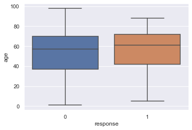

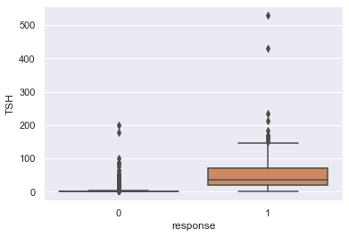

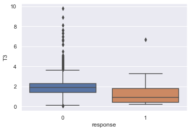

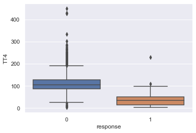

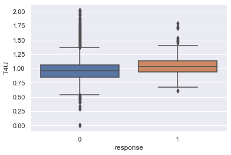

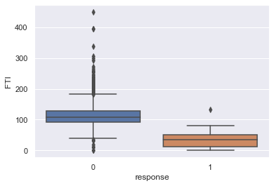

```python
for var in ['age','TSH','T3','TT4','T4U','FTI']:
    sns.boxplot(x='response',y=var,data=data)
    plt.show()
```

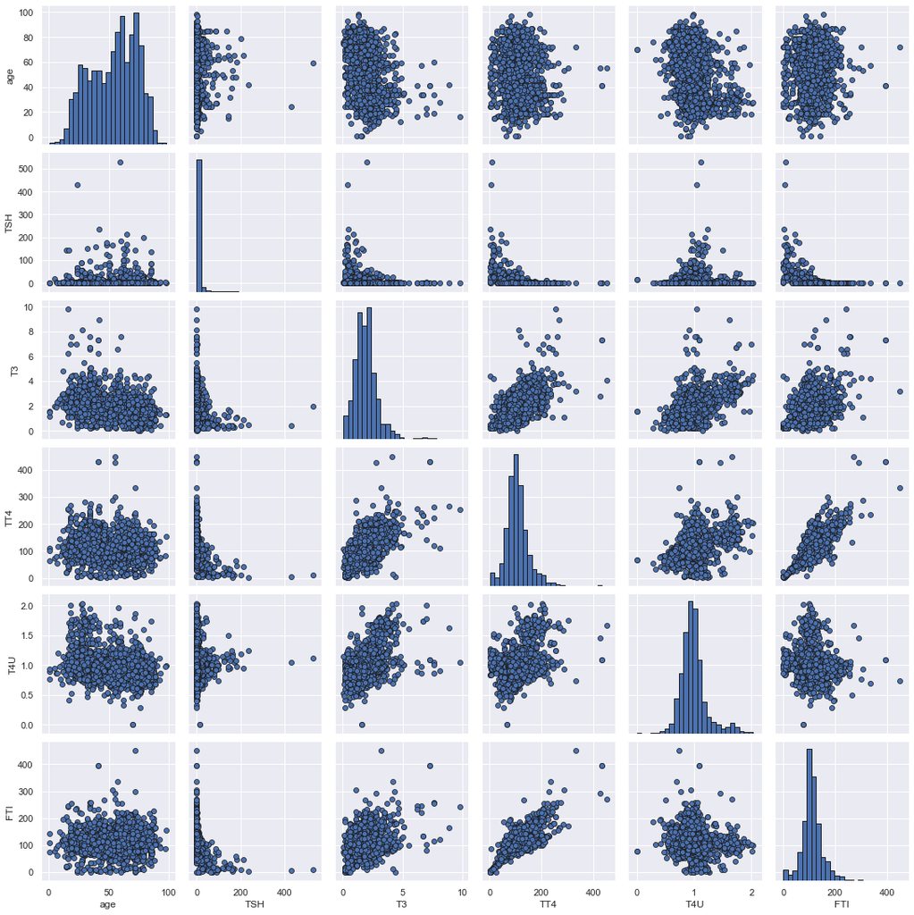

```python
sns.pairplot(data=data[data.columns[1:]],diag_kws={'edgecolor':'k','bins':25},plot_kws={'edgecolor':'k'})
plt.show()
```

```python
# Creating dummies

df_dummies = pd.get_dummies(data=data)
```

```python
df_dummies.sample(10)
```

|  | response | age | TSH | T3 | TT4 | T4U | FTI | sex_F | sex_M | on_thyroxine_f | ... | pregnant_f | pregnant_t | sick_f | sick_t | tumor_f | tumor_t | lithium_f | lithium_t | goitre_f | goitre_t |
| --- | --- | --- | --- | --- | --- | --- | --- | --- | --- | --- | --- | --- | --- | --- | --- | --- | --- | --- | --- | --- | --- |
| 1517 | 0 | 63.0 | 1.30 | 2.0 | 89.0 | 0.87 | 102.0 | 1 | 0 | 1 | ... | 1 | 0 | 1 | 0 | 1 | 0 | 1 | 0 | 1 | 0 |
| 626 | 0 | 72.0 | 6.30 | 1.5 | 94.0 | 0.92 | 102.0 | 1 | 0 | 0 | ... | 1 | 0 | 1 | 0 | 1 | 0 | 1 | 0 | 1 | 0 |
| 641 | 0 | 62.0 | 0.00 | 1.5 | 198.0 | 0.94 | 211.0 | 1 | 0 | 1 | ... | 1 | 0 | 1 | 0 | 1 | 0 | 1 | 0 | 1 | 0 |
| 2016 | 0 | 23.0 | 0.00 | 2.6 | 139.0 | 0.90 | 153.0 | 1 | 0 | 1 | ... | 1 | 0 | 1 | 0 | 1 | 0 | 1 | 0 | 1 | 0 |
| 1627 | 0 | 61.0 | 0.04 | 0.8 | 74.0 | 0.75 | 99.0 | 1 | 0 | 1 | ... | 1 | 0 | 1 | 0 | 1 | 0 | 1 | 0 | 1 | 0 |
| 1523 | 0 | 34.0 | 0.20 | 5.0 | 223.0 | 1.69 | 131.0 | 1 | 0 | 1 | ... | 0 | 1 | 1 | 0 | 1 | 0 | 1 | 0 | 1 | 0 |
| 1802 | 0 | 30.0 | 1.70 | 1.9 | 120.0 | 0.98 | 122.0 | 0 | 1 | 1 | ... | 1 | 0 | 1 | 0 | 1 | 0 | 1 | 0 | 1 | 0 |
| 2589 | 0 | 67.0 | 1.50 | 1.9 | 162.0 | 1.17 | 138.0 | 0 | 1 | 1 | ... | 1 | 0 | 1 | 0 | 1 | 0 | 1 | 0 | 1 | 0 |
| 1362 | 0 | 32.0 | 0.03 | 3.7 | 139.0 | 1.34 | 104.0 | 1 | 0 | 1 | ... | 0 | 1 | 1 | 0 | 1 | 0 | 1 | 0 | 1 | 0 |
| 4 | 1 | 77.0 | 7.30 | 1.2 | 57.0 | 1.28 | 44.0 | 0 | 1 | 1 | ... | 1 | 0 | 1 | 0 | 1 | 0 | 1 | 0 | 1 | 0 |

10 rows × 25 columns

```python
# train test split
from sklearn.model_selection import train_test_split

X = df_dummies.drop('response',axis=1)
Y = df_dummies['response']

X_train, X_test, y_train, y_test = train_test_split(X, Y, test_size=0.20, random_state=42)
```

```python
print("Training set shape",X_train.shape)
print("Test set shape",X_test.shape)
```

```
Training set shape (1600, 24)
Test set shape (400, 24)
```

## *Model using sklearn*

```python
# building logistic model
from sklearn.linear_model import LogisticRegression
```

```
LogisticRegression(
    penalty='l2',
    *,
    dual=False,
    tol=0.0001,
    C=1.0,
    fit_intercept=True,
    intercept_scaling=1,
    class_weight=None,
    random_state=None,
    solver='lbfgs',
    max_iter=100,
    multi_class='auto',
    verbose=0,
    warm_start=False,
    n_jobs=None,
    l1_ratio=None,
)
```

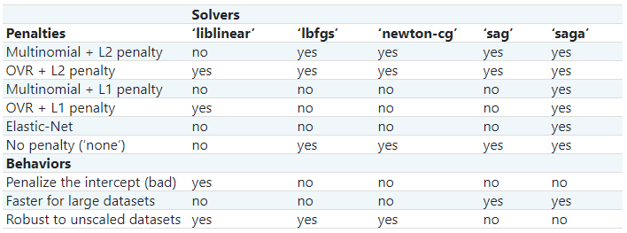

```python
clf = LogisticRegression()
```

```python
clf.fit(X_train,y_train)
```

```
LogisticRegression()
```

```python
clf.intercept_
```

```
array([0.45643263])
```

```python
clf.coef_
```

```
array([[ 0.02561091,  0.01825084, -0.11427088, -0.00587799,  0.38394212,
        -0.09473111,  0.28410109, -0.08730577,  0.68521469, -0.48841937,
         0.87353382, -0.67673849, -0.55122877,  0.7480241 ,  0.27228502,
        -0.07548969,  0.40273279, -0.20593746,  0.40972811, -0.21293278,
         0.25470167, -0.05790634, -0.21663175,  0.41342708]])
```

```python
clf.score(X_test,y_test)
```

```
0.985
```

```python
# prediction

clf.predict(X_test[0:10])
```

```
array([0, 0, 0, 0, 0, 0, 0, 0, 1, 0], dtype=int64)
```

```python
predictions = clf.predict(X_test)
predictions[0:20]
```

```
array([0, 0, 0, 0, 0, 0, 0, 0, 1, 0, 1, 0, 0, 0, 0, 0, 0, 0, 0, 0],
      dtype=int64)
```

### *Predict Probabilities*

```python
# For LogisticRegression estimator, there is a special predict_proba method which
# computes the raw probability values

clf.predict_proba(X_test[0:10])
```

```
array([[9.93827563e-01, 6.17243720e-03],
       [9.98269758e-01, 1.73024184e-03],
       [9.99997504e-01, 2.49554834e-06],
       [6.54775475e-01, 3.45224525e-01],
       [9.99334754e-01, 6.65245841e-04],
       [8.53745917e-01, 1.46254083e-01],
       [9.87768146e-01, 1.22318545e-02],
       [9.98654873e-01, 1.34512683e-03],
       [1.97401459e-01, 8.02598541e-01],
       [9.99920408e-01, 7.95918692e-05]])
```

### *Setting Decision Boundry*

```python
# Selecting Decision Boundary by selecting threshold to minimize False Positive i.e Type 1 error

prob_threshold = 0.5

prob_df=pd.DataFrame(clf.predict_proba(X_test[:10]),columns=['Prob of NO','Prob of YES'])
prob_df['Decision']=(prob_df['Prob of YES']>prob_threshold).apply(int)
prob_df
```

|  | Prob of NO | Prob of YES | Decision |
| --- | --- | --- | --- |
| 0 | 0.993828 | 0.006172 | 0 |
| 1 | 0.998270 | 0.001730 | 0 |
| 2 | 0.999998 | 0.000002 | 0 |
| 3 | 0.654775 | 0.345225 | 0 |
| 4 | 0.999335 | 0.000665 | 0 |
| 5 | 0.853746 | 0.146254 | 0 |
| 6 | 0.987768 | 0.012232 | 0 |
| 7 | 0.998655 | 0.001345 | 0 |
| 8 | 0.197401 | 0.802599 | 1 |
| 9 | 0.999920 | 0.000080 | 0 |

### *Calculating Loss Function*

```python
# Loss function

from sklearn.metrics import log_loss

log_loss(y_test, clf.predict_proba(X_test))
```

```
0.06956369305969068
```

### *Hyper Parameter Tuning*

#### *Value of C*

*C (Inverse of regularization strength):*

- *Inverse of regularization strength helps to avoid overfitting - it penalizes large values of your parameters*
- *It also helps to find Global Minimum by moving to better "solutions" from local minimum to global minimum*
- *The values of C to search should be n-equally-spaced values in log space ranging from 1e-5 to 1e5*

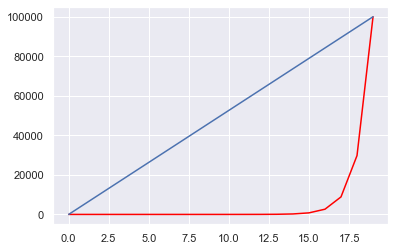

```python
# Setting Values of C

C = np.geomspace(1e-5, 1e5, num=20)

plt.plot(np.geomspace(1e-5, 1e5, num=20), color = 'red') #  uniformly distributed in log space
plt.plot(np.linspace(1e-5, 1e5, num=20)) # uniformly distributed in linear space, instead of log space
```

#### *Selecting Solver*

```python
solvers = ['newton-cg', 'lbfgs', 'liblinear'] # 'sag' (Stochastic Average Gradient) , 'saga' are used for large dataset
```

#### *Writing the Tuning Function*

```python
# Hyperparameter Tuning

CA = []
Logarithmic_Loss = []

for c in C:
    for solver in solvers:
        log_reg2 = LogisticRegression(random_state=10, solver = solver, C=c, max_iter=100, n_jobs = -1)
        log_reg2.fit(X_train, y_train)
        score = log_reg2.score(X_test, y_test)
        CA.append(score)
        print("The CA of C parameter {} and solver {} is {}:".format(c, solver , score))
        pred_proba_t = log_reg2.predict_proba(X_test)
        log_loss2 = log_loss(y_test, pred_proba_t)
        Logarithmic_Loss.append(log_loss2)
        print("The Logg Loss of C parameter {} is {}:".format(c, log_loss2))
        print("-------------------------------------------")
```

```
The CA of C parameter 1e-05 and solver newton-cg is 0.9625:
The Logg Loss of C parameter 1e-05 is 0.10285243747130238:
-------------------------------------------
The CA of C parameter 1e-05 and solver lbfgs is 0.9625:
The Logg Loss of C parameter 1e-05 is 0.10285243021743197:
-------------------------------------------
The CA of C parameter 1e-05 and solver liblinear is 0.96:
The Logg Loss of C parameter 1e-05 is 0.10490293251025067:
-------------------------------------------
The CA of C parameter 3.359818286283781e-05 and solver newton-cg is 0.97:
The Logg Loss of C parameter 3.359818286283781e-05 is 0.08569539058946277:
-------------------------------------------
The CA of C parameter 3.359818286283781e-05 and solver lbfgs is 0.97:
The Logg Loss of C parameter 3.359818286283781e-05 is 0.08569514344486258:
-------------------------------------------
The CA of C parameter 3.359818286283781e-05 and solver liblinear is 0.9625:
The Logg Loss of C parameter 3.359818286283781e-05 is 0.09158222813079185:
-------------------------------------------
The CA of C parameter 0.00011288378916846884 and solver newton-cg is 0.9775:
The Logg Loss of C parameter 0.00011288378916846884 is 0.07779050525107989:
-------------------------------------------
The CA of C parameter 0.00011288378916846884 and solver lbfgs is 0.9775:
The Logg Loss of C parameter 0.00011288378916846884 is 0.07779052406762421:
-------------------------------------------
The CA of C parameter 0.00011288378916846884 and solver liblinear is 0.9725:
The Logg Loss of C parameter 0.00011288378916846884 is 0.08416251140992857:
-------------------------------------------
The CA of C parameter 0.000379269019073225 and solver newton-cg is 0.98:
The Logg Loss of C parameter 0.000379269019073225 is 0.07270940048686682:
-------------------------------------------
The CA of C parameter 0.000379269019073225 and solver lbfgs is 0.98:
The Logg Loss of C parameter 0.000379269019073225 is 0.0727092598993408:
-------------------------------------------
The CA of C parameter 0.000379269019073225 and solver liblinear is 0.975:
The Logg Loss of C parameter 0.000379269019073225 is 0.07917652847091344:
-------------------------------------------
The CA of C parameter 0.0012742749857031334 and solver newton-cg is 0.9825:
The Logg Loss of C parameter 0.0012742749857031334 is 0.06868309037768466:
-------------------------------------------
The CA of C parameter 0.0012742749857031334 and solver lbfgs is 0.9825:
```

[output cut: 125 more lines]

```
The CA of C parameter 29763.51441631313 and solver lbfgs is 0.9825:
The Logg Loss of C parameter 29763.51441631313 is 0.07404532109177192:
-------------------------------------------
The CA of C parameter 29763.51441631313 and solver liblinear is 0.985:
The Logg Loss of C parameter 29763.51441631313 is 0.07592388624978269:
-------------------------------------------
The CA of C parameter 100000.0 and solver newton-cg is 0.985:
The Logg Loss of C parameter 100000.0 is 0.07661500242693237:
-------------------------------------------
The CA of C parameter 100000.0 and solver lbfgs is 0.985:
The Logg Loss of C parameter 100000.0 is 0.07246505340819423:
-------------------------------------------
The CA of C parameter 100000.0 and solver liblinear is 0.985:
The Logg Loss of C parameter 100000.0 is 0.07597521959256393:
-------------------------------------------
```

#### *Important Pointers for Tuning*

- *Similarly, we can choose other parameters like: penality etc. for hyper parameter tuning (which of course would be CPU intensive task and will take more time).*
- *Also, we can choose other metrics like: confusion matrix etc. (which will be discussed further) for selecting the best set of hyper paramters.*
- *Further K-Fold validation can be used on the designed model with tuned parameters, to check the overfitting and performance of the model.*

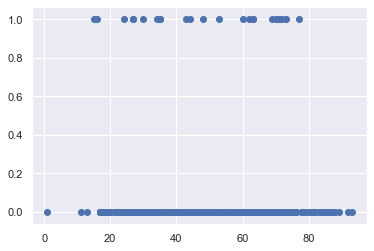

```python
plt.scatter(X_test.age, y_test)
```

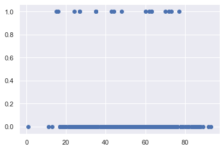

```python
plt.scatter(X_test.age, clf.predict(X_test))
```

### *Learning Curve*

- *Graph that compares the performance of a model on training and testing data over a varying number of training instances.*
- *We should generally see performance improve as the number of training points increases.*

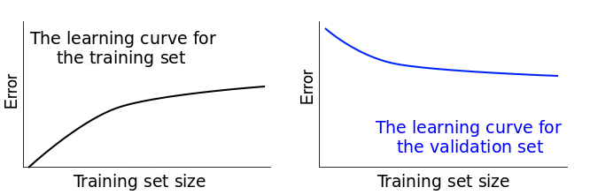

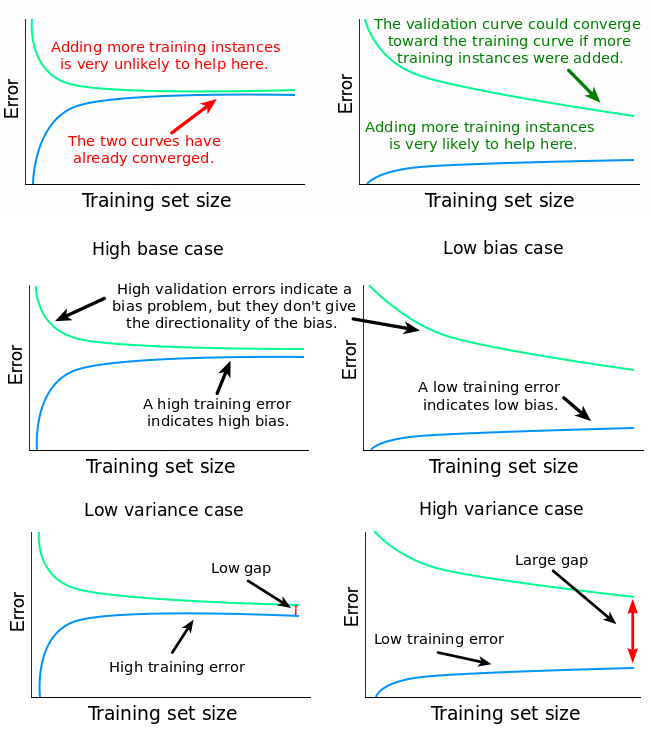

```python
from sklearn.model_selection import learning_curve
```

```python
test_size, train_score, test_score = learning_curve(LogisticRegression(),X,Y,
                                                    cv = 10, train_sizes= np.linspace(0.01,1,20),
                                                    scoring='accuracy', n_jobs=-1, verbose = 1 )
```

```
[learning_curve] Training set sizes: [  18  111  205  299  393  486  580  674  768  862  955 1049 1143 1237
 1331 1424 1518 1612 1706 1800]
```

```
[Parallel(n_jobs=-1)]: Using backend LokyBackend with 4 concurrent workers.
[Parallel(n_jobs=-1)]: Done 200 out of 200 | elapsed:    4.8s finished
```

```python
# finding Mean of Scores
train_score_mean = np.mean(train_score, axis = 1)
test_score_mean = np.mean(test_score, axis = 1)
```

```python
train_score_mean
```

```
array([       nan, 1.        , 0.9795122 , 0.96755853, 0.96641221,
       0.97098765, 0.97034483, 0.97373887, 0.97226562, 0.97529002,
       0.97465969, 0.97530982, 0.97419073, 0.97477769, 0.97595793,
       0.97724719, 0.97740448, 0.97903226, 0.97989449, 0.98077778])
```

```python
test_score_mean
```

```
array([   nan, 0.6895, 0.95  , 0.963 , 0.967 , 0.973 , 0.975 , 0.979 ,
       0.979 , 0.9775, 0.979 , 0.9805, 0.98  , 0.98  , 0.98  , 0.9795,
       0.9785, 0.979 , 0.979 , 0.979 ])
```

```python
# finding STD of Scores
train_score_std = np.std(train_score, axis = 1)
test_score_std = np.std(test_score, axis = 1)
```

```python
train_score_std
```

```
array([       nan, 0.        , 0.00568873, 0.00702341, 0.00518984,
       0.00324686, 0.0016893 , 0.00332092, 0.00218269, 0.00180095,
       0.00218645, 0.00299794, 0.00303702, 0.00281901, 0.00294837,
       0.00259357, 0.00212546, 0.00175022, 0.00161701, 0.00151535])
```

```python
test_score_std
```

```
array([       nan, 0.08292919, 0.0074162 , 0.01004988, 0.01363818,
       0.0143527 , 0.00921954, 0.01067708, 0.01113553, 0.0112361 ,
       0.01135782, 0.0115    , 0.01140175, 0.01140175, 0.01140175,
       0.0115    , 0.01285496, 0.01157584, 0.01113553, 0.01113553])
```

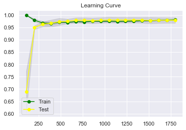

```python
plt.plot(test_size, train_score_mean,'o-',label = 'Train',color = 'green')
plt.plot(test_size, test_score_mean,'o-',label = 'Test', color = 'yellow')
plt.fill_between(test_size, train_score_mean - train_score_std, train_score_mean + train_score_std ,alpha=0.1, color = '#000000')
plt.fill_between(test_size, test_score_mean - test_score_std, test_score_mean + test_score_std, alpha=0.1, color = '#000000')
plt.title('Learning Curve')
plt.legend(loc="best")
```

## *Model using statsmodel*

### *Logit Function*

```python
# importing required library
import statsmodels.api as sm

logit_model=sm.Logit(y_train, sm.add_constant(X_train))
result=logit_model.fit()

print(result.summary2())
```

```
Warning: Maximum number of iterations has been exceeded.
         Current function value: 0.061095
         Iterations: 35
                                      Results: Logit
===========================================================================================
Model:                       Logit                    Pseudo R-squared:         0.737
Dependent Variable:          response                 AIC:                      227.5047
Date:                        2020-07-06 22:46         BIC:                      313.5489
No. Observations:            1600                     Log-Likelihood:           -97.752
Df Model:                    15                       LL-Null:                  -371.35
Df Residuals:                1584                     LLR p-value:              5.7040e-107
Converged:                   0.0000                   Scale:                    1.0000
No. Iterations:              35.0000
-------------------------------------------------------------------------------------------
                          Coef.      Std.Err.      z    P>|z|      [0.025         0.975]
-------------------------------------------------------------------------------------------
const                     -2.3806  8799184.1321 -0.0000 1.0000 -17246086.3728 17246081.6117
age                        0.0230        0.0122  1.8869 0.0592        -0.0009        0.0469
TSH                        0.0184        0.0078  2.3681 0.0179         0.0032        0.0335
T3                        -0.2409        0.3690 -0.6527 0.5139        -0.9641        0.4824
TT4                       -0.0316        0.0433 -0.7311 0.4647        -0.1164        0.0532
T4U                        2.4094        2.7747  0.8684 0.3852        -3.0289        7.8477
FTI                       -0.0726        0.0430 -1.6890 0.0912        -0.1567        0.0116
sex_F                     -0.6461           nan     nan    nan            nan           nan
sex_M                     -1.0735           nan     nan    nan            nan           nan
on_thyroxine_f            -5.0682  8530267.6990 -0.0000 1.0000 -16719022.5367 16719012.4004
on_thyroxine_t            -6.8069  8638675.1369 -0.0000 1.0000 -16931498.9493 16931485.3355
antithyroid_medication_f  -1.3282 27180941.7365 -0.0000 1.0000 -53273668.1976 53273665.5412
antithyroid_medication_t  -3.8764 27240294.6331 -0.0000 1.0000 -53390000.2854 53389992.5327
thyroid_surgery_f         -0.3974  3193314.9033 -0.0000 1.0000  -6258782.5992  6258781.8044
thyroid_surgery_t          1.3029  2941436.2754  0.0000 1.0000  -5765107.8596  5765110.4654
pregnant_f                -0.9611 12888034.0452 -0.0000 1.0000 -25260083.5213 25260081.5991
pregnant_t                -2.7970 12775624.9972 -0.0000 1.0000 -25039767.6715 25039762.0776
sick_f                    -1.4532 17986943.1830 -0.0000 1.0000 -35253762.2839 35253759.3775
sick_t                    -2.3073 17982115.9651 -0.0000 1.0000 -35244301.9646 35244297.3501
tumor_f                    7.4135  4984220.0162  0.0000 1.0000  -9768884.3094  9768899.1363
tumor_t                  -11.1852  4975388.7665 -0.0000 1.0000  -9751593.9766  9751571.6063
lithium_f                  8.6362  3592001.1590  0.0000 1.0000  -7040184.2677  7040201.5402
lithium_t                -12.4079  3556598.3622 -0.0000 1.0000  -6970817.1053  6970792.2895
goitre_f                  -2.3393 10849946.6280 -0.0000 1.0000 -21265506.9643 21265502.2857
goitre_t                  -1.4323 10849946.6280 -0.0000 1.0000 -21265506.0573 21265503.1927
===========================================================================================
```

```python
result.aic
```

```
227.50473232954107
```

```python
result.df_resid
```

```
1584.0
```

```python
result.fittedvalues
```

```
1530   -6.219555
331    -7.141625
1264   -8.727347
1059   -7.064797
612    -8.831995
          ...
1776   -6.395996
2046   -3.065500
1334   -8.106192
2318   -3.452439
1770   -4.160948
Length: 1600, dtype: float64
```

### *Generalized Linear Model*

```python
# using Generalized Linear Model

mdl = sm.GLM(y_train, sm.add_constant(X_train), family=sm.families.Binomial()).fit()
mdl.summary()
```

Generalized Linear Model Regression Results

| Dep. Variable: | response | No. Observations: | 1600 |
| --- | --- | --- | --- |
| Model: | GLM | Df Residuals: | 1584 |
| Model Family: | Binomial | Df Model: | 15 |
| Link Function: | logit | Scale: | 1.0000 |
| Method: | IRLS | Log-Likelihood: | -97.752 |
| Date: | Mon, 06 Jul 2020 | Deviance: | 195.50 |
| Time: | 22:46:01 | Pearson chi2: | 6.90e+03 |
| No. Iterations: | 22 |  |  |
| Covariance Type: | nonrobust |  |  |

|  | coef | std err | z | P>\|z\| | [0.025 | 0.975] |
| --- | --- | --- | --- | --- | --- | --- |
| const | -3.8139 | 4854.683 | -0.001 | 0.999 | -9518.817 | 9511.189 |
| age | 0.0230 | 0.012 | 1.887 | 0.059 | -0.001 | 0.047 |
| TSH | 0.0184 | 0.008 | 2.368 | 0.018 | 0.003 | 0.034 |
| T3 | -0.2409 | 0.369 | -0.653 | 0.514 | -0.964 | 0.482 |
| TT4 | -0.0316 | 0.043 | -0.731 | 0.465 | -0.116 | 0.053 |
| T4U | 2.4094 | 2.775 | 0.868 | 0.385 | -3.029 | 7.848 |
| FTI | -0.0726 | 0.043 | -1.689 | 0.091 | -0.157 | 0.012 |
| sex_F | -1.6933 | 2427.341 | -0.001 | 0.999 | -4759.195 | 4755.808 |
| sex_M | -2.1206 | 2427.341 | -0.001 | 0.999 | -4759.622 | 4755.381 |
| on_thyroxine_f | -1.0376 | 2427.341 | -0.000 | 1.000 | -4758.539 | 4756.464 |
| on_thyroxine_t | -2.7763 | 2427.341 | -0.001 | 0.999 | -4760.278 | 4754.725 |
| antithyroid_medication_f | -0.6328 | 2427.341 | -0.000 | 1.000 | -4758.135 | 4756.869 |
| antithyroid_medication_t | -3.1810 | 2427.341 | -0.001 | 0.999 | -4760.683 | 4754.321 |
| thyroid_surgery_f | -2.7571 | 2427.341 | -0.001 | 0.999 | -4760.259 | 4754.745 |
| thyroid_surgery_t | -1.0568 | 2427.341 | -0.000 | 1.000 | -4758.559 | 4756.445 |
| pregnant_f | -0.9890 | 2427.342 | -0.000 | 1.000 | -4758.493 | 4756.515 |
| pregnant_t | -2.8249 | 2427.343 | -0.001 | 0.999 | -4760.329 | 4754.680 |
| sick_f | -1.4799 | 2427.341 | -0.001 | 1.000 | -4758.982 | 4756.022 |
| sick_t | -2.3340 | 2427.341 | -0.001 | 0.999 | -4759.836 | 4755.168 |
| tumor_f | 7.9235 | 6962.982 | 0.001 | 0.999 | -1.36e+04 | 1.37e+04 |
| tumor_t | -11.7374 | 8210.512 | -0.001 | 0.999 | -1.61e+04 | 1.61e+04 |
| lithium_f | 8.3162 | 2.34e+04 | 0.000 | 1.000 | -4.58e+04 | 4.58e+04 |
| lithium_t | -12.1301 | 2.81e+04 | -0.000 | 1.000 | -5.5e+04 | 5.5e+04 |
| goitre_f | -2.3604 | 2427.341 | -0.001 | 0.999 | -4759.862 | 4755.141 |
| goitre_t | -1.4534 | 2427.341 | -0.001 | 1.000 | -4758.955 | 4756.048 |

*To evaluate the performance of a logistic regression model, Deviance is used in lieu of sum of squares calculations.*

- *Null Deviance* *indicates the response predicted by a model with nothing but an intercept.*
- *Model deviance* *indicates the response predicted by a model on adding independent variables. If the model deviance is significantly smaller than the null deviance, one can conclude that the parameter or set of parameters significantly improved model fit.*

# *Classification Metrics*

## *Confusion Matrix*

### *What is a Confusion Matrix?*

*A confusion matrix is a summary of prediction results on a classification problem. The number of correct and incorrect predictions are summarized with count values and broken down by each class. This is the key to the confusion matrix. The confusion matrix shows the ways in which your classification model is confused when it makes predictions.*

*Confusion Matrix gives insight not only into the errors being made by your classifier but more importantly the types of errors that are being made.*

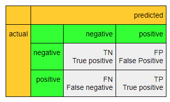

#### *True Positive*

*True positive is nothing but the case where the actual value as well as the predicted value are true. The patient has been diagnosed with cancer, and the model also predicted that the patient had cancer.*

#### *False Negative*

*In false negative, the actual value is true, but the predicted value is false, which means that the patient has cancer, but the model predicted that the patient did not have cancer.*

#### *False Positive*

_This is the case where the predicted value is true, but the actual value is false. Here, the model predicted that the patient had cancer, but in reality, the patient doesn’t have cancer. This is also known as *Type 1 Error*._

#### *True Negative*

*Now, Lets calculate using the below matrix:*

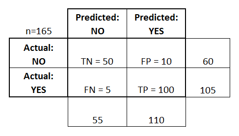

#### *Accuracy*

*Overall, how often is the classifier correct?*

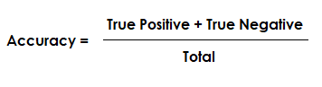

*Accuracy = (100+50)/165 = 0.91*

#### *Misclassification Rate/Error Rate*

*Overall, how often is it wrong?*

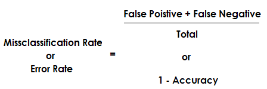

*Error Rate = (10+5)/165 = 0.09*

#### *Sensitivity/Recall/True Positive Rate*

*When it's actually yes, how often does it predict yes?*

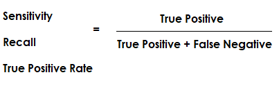

*Senstivity/Recall= 100/105 = 0.95*

#### *False Positive Rate*

*When it's actually no, how often does it predict yes?*

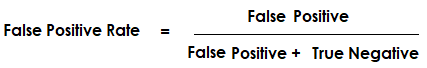

*False Positive Rate = 10/60 = 0.17*

#### *Specificity/True Negative Rate*

*When it's actually no, how often does it predict no?*

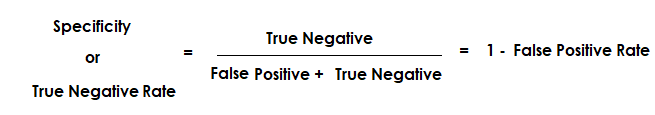

*Specificity = 50/60 = 0.83*

#### *Precision*

*When it predicts yes, how often is it correct?*

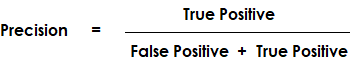

*Precision = 100/110 = 0.91*

#### *Prevalence*

*How often does the yes condition actually occur in our sample?*

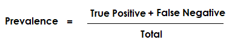

*Prevalence = 105/165 = 0.64*

```python
from sklearn.metrics import accuracy_score,confusion_matrix
```

```python
# Generating Confusion Matrix
conf_mat = confusion_matrix(y_test, clf.predict(X_test))
conf_mat
```

```
array([[376,   1],
       [  5,  18]], dtype=int64)
```

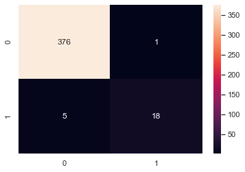

```python
# Heat map of Confusion Matrix
sns.heatmap(conf_mat, annot= True, fmt="d")
```

```python
accuracy_score(y_test, clf.predict(X_test))
```

```
0.985
```

## *F-Beta Score*

*F-Score combines precision and recall into one metric. The higher the score the better our model is.*

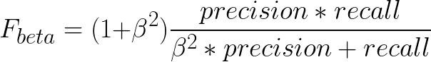

*When choosing beta in your F-beta score the more you care about recall over precision the higher beta you should choose. For example, with F1 score we care equally about recall and precision with F2 score, recall is twice as important to us.*

*With 0<beta<1 we care more about precision and so the higher the threshold the higher the F beta score. When beta>1 our optimal threshold moves toward lower thresholds and with beta=1 it is somewhere in the middle.*

```python
from sklearn.metrics import fbeta_score

fbeta_score(y_test, predictions,0.5)
```

```
0.9090909090909091
```

### *F1 score (beta=1)*

*It’s the harmonic mean between precision and recall.*

- *Accuracy is used when the True Positives and True negatives are more important while F1-score is used when the False Negatives and False Positives are crucial*
- *Accuracy can be used when the class distribution is similar while F1-score is a better metric when there are imbalanced classes as in the above case.*
- *In most real-life classification problems, imbalanced class distribution exists and thus F1-score is a better metric to evaluate our model on.*

*Why harmonic mean?* *Since the harmonic mean of a list of numbers skews strongly toward the least elements of the list, it tends (compared to the arithmetic mean) to mitigate the impact of large outliers and aggravate the impact of small ones.*

```python
from sklearn.metrics import f1_score

f1_score(y_test, predictions)
```

```
0.8571428571428571
```

## *Classification Report*

*The report shows the main classification metrics precision, recall and f1-score on a per-class basis. The metrics are calculated by using true and false positives, true and false negatives. Positive and negative in this case are generic names for the predicted classes.*

```python
from sklearn.metrics import classification_report

print(classification_report(y_test, predictions))

# support is number of instances of that class in the data
```

```
              precision    recall  f1-score   support

           0       0.99      1.00      0.99       377
           1       0.95      0.78      0.86        23

    accuracy                           0.98       400
   macro avg       0.97      0.89      0.92       400
weighted avg       0.98      0.98      0.98       400
```

## *ROC AUC Curve*

### *ROC*

*The **Receiver operating characteristic (ROC)**, or the ROC curve, is a graphical plot that illustrates the performance of a binary classifier system as its discrimination threshold is varied between 0.0 and 1.0. The curve is created by plotting the **True positive rate (TPR)/Sensitivity** against the **False positive rate (FPR)** at various threshold settings.*

*For different threshold values we will get different TPR and FPR. So, in order to visualise which threshold is best suited for the classifier we plot the ROC curve.*

```python
from sklearn.metrics import roc_curve
from sklearn.metrics import roc_auc_score
```

```python
# calculate roc curve
fpr, tpr, thresholds = roc_curve(y_test, clf.predict_proba(X_test)[:,1])
```

```python
def plot_roc_curve(fpr, tpr):
    plt.plot(fpr, tpr, color='orange', label='ROC')
    plt.plot([0, 1], [0, 1], color='darkblue', linestyle='--')
    plt.title('Receiver Operating Characteristic (ROC) Curve')
    plt.legend()
    plt.show()
```

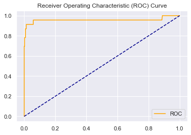

```python
plot_roc_curve(fpr, tpr)
```

- *Smaller values on the x-axis of the plot indicate lower false positives and higher true negatives.*
- *Larger values on the y-axis of the plot indicate higher true positives and lower false negatives.*

*Now basis the domain requirement we can select the required threshold, to maximize our TP or TN.*

*Remember, our ROC curve should be above the center line only. Otherwise, the model is not good.*

```python
print(thresholds)
```

```
[1.99786285e+00 9.97862852e-01 6.19237747e-01 6.01132718e-01
 5.34142198e-01 3.45224525e-01 3.03630798e-01 2.14384511e-01
 1.94815674e-01 5.52891662e-02 5.41150927e-02 5.10223769e-02
 6.26380523e-03 6.17243720e-03 1.21278829e-05 1.03346136e-05
 8.01843294e-06 7.57675697e-06 1.49632425e-16]
```

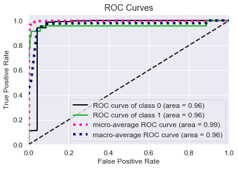

```python
skplt.metrics.plot_roc(y_test, clf.predict_proba(X_test))
```

### *AUC*

*Area Under the Curve or AUC ROC curve is nothing but the area under the curve calculated in the ROC space. One of the easy ways to calculate the AUC score is using the trapezoidal rule, which is adding up all trapezoids under the curve. Theoretical range of the AUC ROC curve score is between 0 and 1. Higher the AUC, better is the model.*

```python
# calculate AUC
auc = roc_auc_score(y_test, clf.predict_proba(X_test)[:,1])
print('AUC: %.3f' % auc)
```

```
AUC: 0.957
```

## *Precision Recall Curve*

*The precision-recall curve shows the tradeoff between precision and recall for different threshold. A high area under the curve represents both high recall and high precision, where high precision relates to a low false positive rate, and high recall relates to a low false negative rate.*

```python
from sklearn.metrics import precision_recall_curve
from sklearn.metrics import auc
```

```python
# calculate precision-recall curve
precision, recall, thresholds = precision_recall_curve(y_test, clf.predict_proba(X_test)[:,1])
```

```python
# calculate precision-recall AUC
auc_val = auc(recall, precision)
print(auc_val)
```

```
0.912033098824284
```

```python
def plot_roc_curve(recall, precision):
    plt.plot(recall, precision, color='orange', label='PR')
    plt.plot([0, 1], [1, 0], color='darkblue', linestyle='--')
    plt.title('Precision Recall Curve')
    plt.legend()
    plt.show()
```

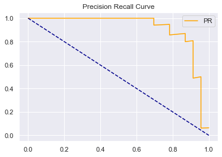

```python
plot_roc_curve(recall, precision)
# X-axis should always be RECALL
```

- *ROC curves should be used when there are roughly equal numbers of observations for each class.*
- *Precision-Recall curves should be used when there is a moderate to large class imbalance.*

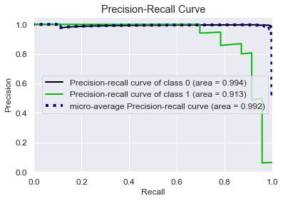

```python
skplt.metrics.plot_precision_recall(y_test, clf.predict_proba(X_test))
```

## *Kappa Coefficient*

*Cohen's kappa coefficient is a statistic which measures inter-rater agreement for qualitative (categorical) items. Kappa Statistic is a metric that compares an observed accuracy with an expected accuracy (Random Chance).*

*This metric typically varies from 0 (random agreement between raters) to 1 (complete agreement between raters).*

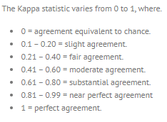

*Example:*

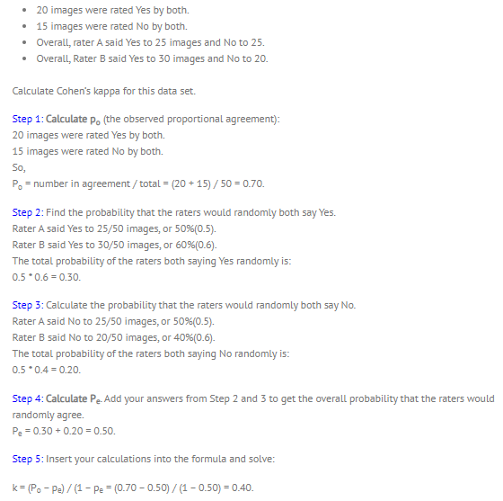

```python
from sklearn.metrics import cohen_kappa_score

cohen_kappa_score(y_test, predictions)
```

```
0.8493030264975512
```

## *Balanced Accuracy*

*Balanced accuracy is calculated as the average of the proportion corrects of each class individually.*

*Balanced accuracy is based on two more commonly used metrics: sensitivity (also known as true positive rate or recall) and specificity (also known as false positive rate).*

```python
from sklearn.metrics import balanced_accuracy_score
```

```python
balanced_accuracy_score(y_test, predictions)
```

```
0.8899780878791373
```

## *Brier Loss*

*Brier score measures the mean squared difference between the predicted probability assigned to the possible outcomes for item i, and the actual outcome.*

- *The best possible Brier score is 0, for total accuracy.*
- *The lowest possible score is 1, which mean the prediction was wholly inaccurate.*

```python
from sklearn.metrics import brier_score_loss
```

```python
brier_score_loss(y_test, clf.predict_proba(X_test)[:,1])
```

```
0.013583837820125176
```

## *Log Loss/Cross Entropy*

*Logarithmic Loss or Log Loss, works by penalising the false classifications. It works well for multi-class classification. When working with Log Loss, the classifier must assign probability to each class for all the samples.*

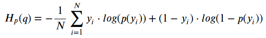

*Log Loss has no upper bound and it exists on the range [0, ∞). Log Loss nearer to 0 indicates higher accuracy, whereas if the Log Loss is away from 0 then it indicates lower accuracy.*

```python
from sklearn.metrics import log_loss
```

```python
log_loss(y_test, clf.predict_proba(X_test))
```

```
0.06956369305969068
```

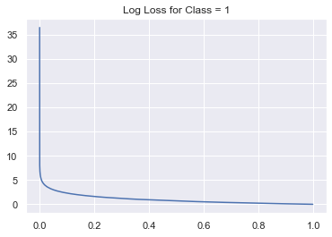

```python
# Plotting log loss for the positive outcome

y_prob = clf.predict_proba(X_test)[:,1].tolist()
y_prob.sort()

plt.plot(y_prob, -np.log(y_prob))
#plt.xlabel('Probability of Class 1')
#plt.ylabel('Log Loss')
plt.title('Log Loss for Class = 1')
plt.show()

# so the below graph shows us, as the predicted probability of the true class gets closer to zero,
# the loss increases exponentially
```

## *KS Statistics*

*Kolmogorov-Smirnov (KS) Statistics is one of the most important metrics used for validating predictive models. It is widely used in BFSI domain. If you are a part of risk or marketing analytics team working on project in banking, you must have heard of this metrics.*

*It compares the two cumulative distributions and returns the maximum difference between them. It is a non-parametric test which means you don't need to test any assumption related to the distribution of data. In KS Test, Null hypothesis states null both cumulative distributions are similar or have been extracted from same distribution. Rejecting the null hypothesis means cumulative distributions are different.*

*In simple words, it helps us to understand how well our predictive model is able to discriminate between events and non-events.Suppose you are building a propensity model in which objective is to identify prospects who are likely to buy a particular product. In this case, dependent (target) variable is in binary form which has only two outcomes : 0 (Non-event) or 1 (Event). "Event" means people who purchased the product. "Non-event" refers to people who didn't buy the product. KS Statistics measures whether model is able to distinguish between prospects and non-prospects.*

### *Plotting*

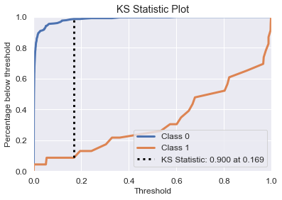

```python
from scikitplot.metrics import plot_ks_statistic

plot_ks_statistic(y_test, clf.predict_proba(X_test))
```

### *Decile Method*

```python
data_ks = pd.DataFrame(list(zip(clf.predict_proba(X_test)[:,1].tolist(),predictions.tolist())), columns = ['probab','class1'])
```

```python
def ks(data=None, target=None, prob=None):
    data['target0'] = 1 - data[target]
    data['bucket'] = pd.qcut(data[prob], 10)
    grouped = data.groupby('bucket', as_index = False)

    kstable = pd.DataFrame()
    kstable['min_prob'] = grouped.min()[prob]
    kstable['max_prob'] = grouped.max()[prob]
    kstable['events']   = grouped.sum()[target]
    kstable['nonevents'] = grouped.sum()['target0']
    kstable = kstable.sort_values(by="min_prob", ascending=False).reset_index(drop = True)
    kstable['event_rate'] = (kstable.events / data[target].sum()).apply('{0:.2%}'.format)
    kstable['nonevent_rate'] = (kstable.nonevents / data['target0'].sum()).apply('{0:.2%}'.format)
    kstable['cum_eventrate']=(kstable.events / data[target].sum()).cumsum()
    kstable['cum_noneventrate']=(kstable.nonevents / data['target0'].sum()).cumsum()

    kstable['KS'] = np.round(kstable['cum_eventrate']-kstable['cum_noneventrate'], 3) * 100

    #Formating
    kstable['cum_eventrate']= kstable['cum_eventrate'].apply('{0:.2%}'.format)
    kstable['cum_noneventrate']= kstable['cum_noneventrate'].apply('{0:.2%}'.format)
    kstable.index = range(1,11)
    kstable.index.rename('Decile', inplace=True)
    pd.set_option('display.max_columns', 9)

    #Display KS
    from colorama import Fore
    print(Fore.RED + "KS is " + str(max(kstable['KS']))+"%"+ " at decile " + str((kstable.index[kstable['KS']==max(kstable['KS'])][0])))
    return(kstable)
```

```python
ks(data_ks,'class1','probab')
```

```
KS is 94.5% at decile 1
```

| Decile | min_prob | max_prob | events | nonevents | event_rate | nonevent_rate | cum_eventrate | cum_noneventrate | KS |
| --- | --- | --- | --- | --- | --- | --- | --- | --- | --- |
| 1 | 6.174058e-02 | 0.997863 | 19 | 21 | 100.00% | 5.51% | 100.00% | 5.51% | 94.5 |
| 2 | 1.223185e-02 | 0.060050 | 0 | 40 | 0.00% | 10.50% | 100.00% | 16.01% | 84.0 |
| 3 | 4.990576e-03 | 0.011755 | 0 | 40 | 0.00% | 10.50% | 100.00% | 26.51% | 73.5 |
| 4 | 2.406792e-03 | 0.004967 | 0 | 40 | 0.00% | 10.50% | 100.00% | 37.01% | 63.0 |
| 5 | 1.316460e-03 | 0.002244 | 0 | 40 | 0.00% | 10.50% | 100.00% | 47.51% | 52.5 |
| 6 | 5.998980e-04 | 0.001305 | 0 | 40 | 0.00% | 10.50% | 100.00% | 58.01% | 42.0 |
| 7 | 2.384707e-04 | 0.000534 | 0 | 40 | 0.00% | 10.50% | 100.00% | 68.50% | 31.5 |
| 8 | 9.318771e-05 | 0.000234 | 0 | 40 | 0.00% | 10.50% | 100.00% | 79.00% | 21.0 |
| 9 | 8.018433e-06 | 0.000092 | 0 | 40 | 0.00% | 10.50% | 100.00% | 89.50% | 10.5 |
| 10 | 1.496324e-16 | 0.000008 | 0 | 40 | 0.00% | 10.50% | 100.00% | 100.00% | 0.0 |

*By decile method, the max value of KS separation should lie between Decile 1 to 4.*

### *KS Test*

```python
from scipy.stats import ks_2samp
```

```python
ks_2samp(clf.predict_proba(X_test)[:,0],clf.predict_proba(X_test)[:,1])
```

```
Ks_2sampResult(statistic=0.915, pvalue=8.969697160765615e-180)
```

*Value of p is less than 0.05 therefore we can reject the null hypothesis and can say the samples are different.*

## *Gini Coefficient*

*Gini Coefficient tells us about the differentiating power of the model. In a ROC Curve, it is the area between the random model and the created model (ROC Curve).*

*Gini is measured in values between 0 and 1, where a score of 1 means that the model is 100% accurate in predicting the outcome. A score of 1 only exists in theory. In practice, the closer the Gini is to 1, the better. Whereas, a Gini score equal to 0 means the model is entirely inaccurate.*

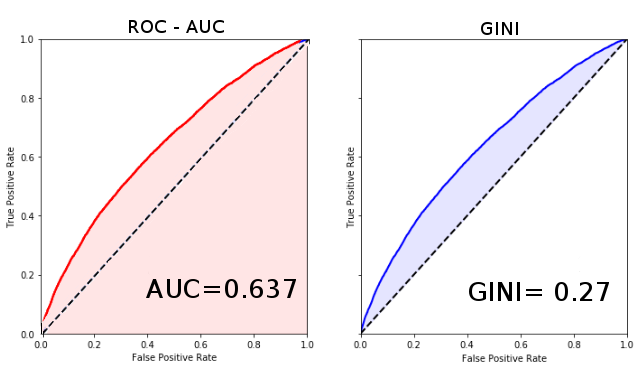

*A higher Gini is beneficial to the bottom line because requests can be assessed more accurately, which means acceptance can be increased and at less risk.*

```
GINI COEFF = 2*AUC - 1
```

```python
auc = roc_auc_score(y_test, clf.predict_proba(X_test)[:,1])

gini_coeff = 2*auc-1
gini_coeff
```

```
0.9147733825394992
```

## *Gain and Lift Charts*

*Gain or lift is a measure of the effectiveness of a classification model calculated as the ratio between the results obtained with and without the model. Gain and lift charts are visual aids for evaluating performance of classification models. However, in contrast to the confusion matrix that evaluates models on the whole population gain or lift chart evaluates model performance in a portion of the population.*

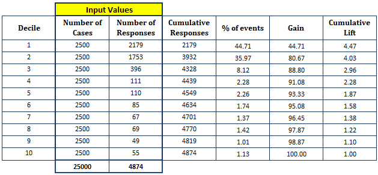

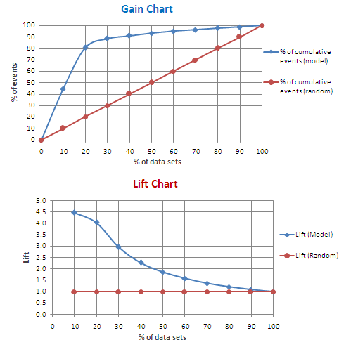

### *Gain Chart*

*Gain at a given decile level is the ratio of cumulative number of targets (events) up to that decile to the total number of targets (events) in the entire data set. This describes the ‘gain’ in targeting a given percentage of the total number of customers using the highest modelled probabilities of responding, rather than targeting them at random.*

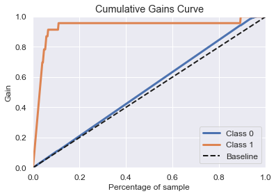

```python
skplt.metrics.plot_cumulative_gain(y_test, clf.predict_proba(X_test))
```

### *Lift Chart*

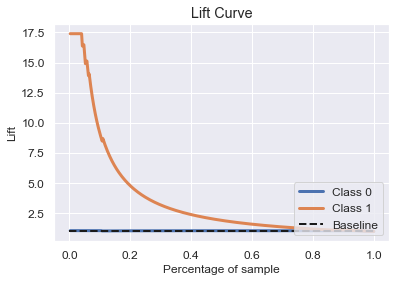

```python
skplt.metrics.plot_lift_curve(y_test, clf.predict_proba(X_test))
```

## *Jaccard Index*

*The Jaccard Index, also known as the Jaccard similarity coefficient, is a statistic used in understanding the similarities between sample sets. The measurement emphasizes similarity between finite sample sets, and is formally defined as the size of the intersection divided by the size of the union of the sample sets.*

**This percentage tells you how similar the two sets are.**

- *Two sets that share all members would be 100% similar. the closer to 100%, the more similarity (e.g. 90% is more similar than 89%).*
- *If they share no members, they are 0% similar.*
- *The midway point — 50% — means that the two sets share half of the members.*

*Examples:*

*A simple example using set notation: How similar are these two sets?*

*A = {0,1,2,5,6}*

*B = {0,2,3,4,5,7,9}*

**Solution: J(A,B)** = |A∩B| / |A∪B|

```
                 = |{0,2,5}| / |{0,1,2,3,4,5,6,7,9}|

                 = 3/9

                 = 0.33
```

```python
from sklearn.metrics import jaccard_score
jaccard_score(y_test, predictions)
```

```
0.75
```

## *Concordance Disordance*

*CUTOFF VALUE :* *Let us consider a binary logistic model in which an event and a non events are classified as (1) and (0) respectively. We get the probability values as an output of the logistic model . We classify the output as event (1) or non event (0), depending upon the cutoff probability value (Popular choice of the cutoff probability is 0.5*). Thus, if the cutoff probability is chosen as 0.5, then all the observations with probability value greater than 0.5 will be classified as event (1) else nonevent (0).*

*It should be noted that in case of classification we may fix our cutoff value; however , for the calculation of the Concordance we do not fix the cutoff value.*

*For the calculation of Concordance, we will make all the possible pairs of (1) and (0). For instance, we have five events (1) and five non events (0), then we have total 25 pairs of ones and zeros (1,0). Further, for each pair we will look at the probability values of one and zero.*

*CASE I: CONCORDANT PAIRS:* *For example , let us consider pair one (1,0), which has the probability as (0.9, 0.6) correspondingly. This means that the probability of 0.9 is considered as event (1) and the probability value of 0.6 is considered as non event(0), in this case. Therefore, for an observation to be classified as an event the cutoff value should be less than 0.9, whereas for an observation to be classified as a non event cutoff should be more than 0.6. For the coexistence of both the cases , the cutoff value of the probability should be less than 0.9 and greater than 0.6. In case of this pair, cutoff value can vary between 0.6 to 0.9. Similarly, can have another example of a pair having probability values (0.3, 0.2), this pair can have cutoff values ranging between 0.3 and 0.2. Such pairs are termed as Concordant pairs.*

*CASE II: DISCORDANT PAIRS:* *Let us take another pair of one and zero (1,0), with probability value as (0.70,0.75) respectively. What can be said about the cutoff value, in this case?? In this case the probability of event is less than the probability of non event. In this case, for an observation to be classified as an event the cutoff value of the probability should be less than 0.70 , whereas for an observation to be classified as an nonevent the cutoff value should be greater than 0.75. Such cases cannot coexist because this is contrary to our definition of the event and non events based upon the cutoff value. Therefore, such pairs are termed as Discordant pairs.*

*CASE III: TIED PAIRS:* *Let us take one more pair of one and zero (1,0), with probability value as (0.65,0.65) respectively. What can be said about the cutoff value, in this case?? In this case the probability of event is equal to the probability of non event. Looking at event’s probability of 0.65, we can say the cutoff value should be less than 0.65, on the other hand , looking at the non event’s probability , we can say that the cutoff value should be greater than 0.65. Big Problem!!!! Solution-> These two cases can coexist if and only if the cutoff value is equal to 0.65. Such pairs are called Tied pairs.*

*INTERPRETATION:* *The total number of Concordant pairs are counted and divided by the total number of pairs. This will give us the value of concordance ratio. The higher the concordance ratio, the better is the model.*

*[CODE REFERENCE](https://incipientanalyst.wordpress.com/2017/08/08/generic-python-code-for-classification-techniques/)*

```python
def concordance_discordance():
        Probability = clf.predict_proba(X_test)
        Probability1 = pd.DataFrame(Probability)
        Probability1.columns = ['Prob_0','Prob_1']
        TruthTable = pd.merge(y_test, Probability1[['Prob_1']], how='inner', left_index=True, right_index=True)
        zeros = TruthTable[(TruthTable['response']==0)].reset_index().drop(['index'], axis = 1)
        ones = TruthTable[(TruthTable['response']==1)].reset_index().drop(['index'], axis = 1)

        from bisect import bisect_left, bisect_right
        zeros_list = sorted([zeros.iloc[j,1] for j in zeros.index])
        zeros_length = len(zeros_list)
        disc = 0
        ties = 0
        conc = 0
        for i in ones.index:
            cur_conc = bisect_left(zeros_list, ones.iloc[i,1])
            cur_ties = bisect_right(zeros_list, ones.iloc[i,1]) - cur_conc
            conc += cur_conc
            ties += cur_ties
        pairs_tested = zeros_length * len(ones.index)
        disc = pairs_tested - conc - ties
        print('Pairs = ', pairs_tested)
        print('Conc = ', conc)
        print('Disc = ', disc)
        print('Tied = ', ties)
        concordance = round(conc/pairs_tested,2)
        discordance = round(disc/pairs_tested,2)
        ties_perc = round(ties/pairs_tested,2)
        Somers_D = round((conc - disc)/pairs_tested,2)
        print('Concordance = ', concordance, '%')
        print('Discordance = ', discordance, '%')
        print('Tied = ', ties_perc, '%')
        print('Somers D = ', Somers_D)
```

```python
concordance_discordance()
```

```
Pairs =  736
Conc =  371
Disc =  365
Tied =  0
Concordance =  0.5 %
Discordance =  0.5 %
Tied =  0.0 %
Somers D =  0.01
```

_Somer’s D is a very commonly used metrics for *measuring credit risk model’s rank ordering power*. The idea behind somers’ D is quite simple. Suppose we have a “good-bad” pair of obs, each obs has score and target variable o or 1 (binary). A pair of obs is called “concordant” if the the obs with target variable 1 has higher score compared with obs with target variable 0. A pair of obs is called “disconcordant” if the the obs with target variable 1 has lower score compared with obs with target variable 0. A pair of obs is called “tie” if obs with target variable 1 has equal score with obs with target variable 0._

```
Somer’s D = (Num of Concordant Pair- Num of Disconcordant Pair) / Total number of pari (include tie)
```

## *Hosmer-Lemeshow Test*

*A large value of Chi-squared (with small p-value < 0.05) indicates poor fit and small Chi-squared values (with larger p-value closer to 1) indicate a good logistic regression model fit.*